# ETS priors

## Construct estimate time syptomatic

```r
  #' Construct estimated symptomatic time
  # Limit to data from pre 2012 to avoid reporting bias
  ets_sym <- ets_sym %>%
    mutate(time_symptomatic = starttreatdate - symptonset) %>%
  filter(year <= 2012)
```

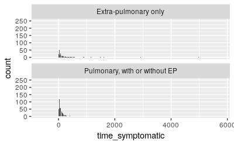

```r
  #' Plot constructed variable
  ets_sym %>%
    drop_na(pulmextrapulm) %>%
    ggplot(aes(x = time_symptomatic)) +
    geom_bar() +
  facet_wrap(~pulmextrapulm, ncol = 1)
```

```r
  #' How many started treatment after sympton onset report and remove
  ets_sym %>%
    filter(time_symptomatic < 0) %>%
    dplyr::select(time_symptomatic)
```

| time_symptomatic |
| --- |
| -24 days |
| -10 days |
| -22 days |
| -69 days |
| -58 days |
| -15 days |
| -15 days |
| -25 days |
| -3 days |
| -7 days |

[output cut: 114 more lines]

```r
  ets_sym <- ets_sym %>%
    filter(time_symptomatic > 0)
```

```r
  #' Scale time symptomatic to a year
  ets_sym$time_symptomatic <- ets_sym$time_symptomatic/365.25
```

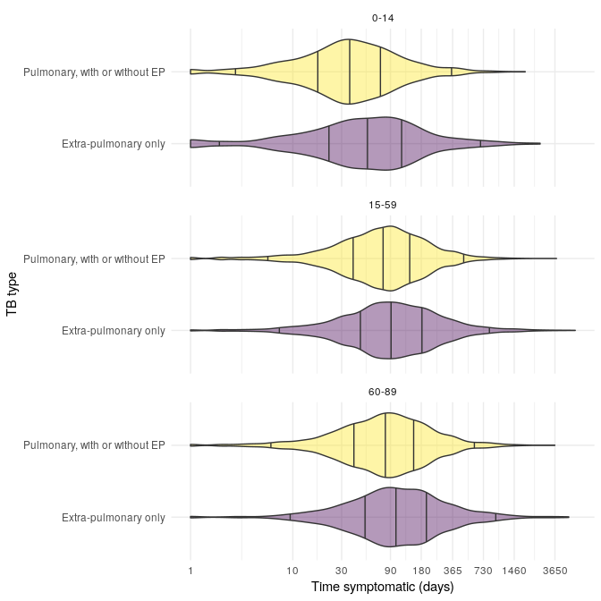

```r
  #' Plot
  ets_sym %>%
    drop_na(pulmextrapulm) %>%
    mutate(age_stage = age_stage %>%
             fct_recode(`0-14` = "child",
                        `15-59` = "adult",
                        `60-89` = "older adult")) %>%
    ggplot(aes(x = pulmextrapulm, y= as.numeric(time_symptomatic) * 365.25,
               fill = pulmextrapulm)) +
    scale_y_log10(breaks = c(0, 1, 10, 30, 90, 180, 365, 365*2, 365*4, 365*10)) +
  coord_flip() +
    geom_violin(alpha = 0.4, draw_quantiles = c(0.025, 0.25, 0.5, 0.75, 0.975)) +
  facet_wrap(~age_stage, ncol = 1) +
  scale_fill_viridis(discrete = TRUE) +
  theme_minimal() +
  theme(legend.position = "none") +
  labs(x = "TB type",
       y = "Time symptomatic (days)")
```

```r
ggsave("figure/time_to_treatment.png", dpi = 330)
```

```r
ets_sym <- ets_sym %>%
  drop_na(pulmextrapulm)
```

Some evidence that chilren and and pulmonary TB cases are treated more quickly than adults and extra pulmonary cases. Little evidence that adults and older adults are treated differently.

```r
  #' Fit gamma distribution to the data
sym_gamma <- ets_sym %>%
  mutate(age_stage = age_stage %>%
           fct_collapse(`adult` = c("adult", "older adult"))) %>%
  group_by(pulmextrapulm, age_stage) %>%
  drop_na(time_symptomatic) %>%
  nest %>%
  mutate(fit = map(data, ~fitdistr(.$time_symptomatic %>%
                                  as.numeric %>%
                                  na.omit,
                                  densfun = "gamma",
                                  lower = c(0, 0)))) %>%
  mutate(density = map(data, ~ density(.$time_symptomatic %>% as.numeric))) %>%
  mutate(density = map(density, ~ data.frame(x = .$x, y = .$y))) %>%
  mutate(fitted_y = map2(fit, density, ~ dgamma(.y$x,
                                                .x$estimate["shape"],
                                                .x$estimate["rate"]))
  ) %>%
  mutate(model_params = map(fit, ~ data.frame(parameter = "nu",
                                              description = "gamma",
                                              shape1 = .$estimate[1],
                                              shape2 = .$estimate[2])))
```

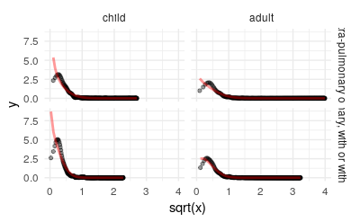

```r
sym_gamma %>%
  dplyr::select(-fit, -data, -model_params) %>%
  unnest() %>%
  ggplot(aes(x = sqrt(x),y = y)) +
    geom_point(size = 1.2, alpha = 0.4) +
    geom_line(aes(y = fitted_y),
              color = "red", size = 1, alpha = 0.4) +
    theme_minimal() +
      facet_grid(pulmextrapulm ~ age_stage)
```

```r
  #' Store fit
  symptomatic_time <- sym_gamma %>%
  dplyr::select(-data, -fit, -density, -fitted_y) %>%
  unnest

symptomatic_time
```

| pulmextrapulm | age_stage | parameter | description | shape1 | shape2 |
| --- | --- | --- | --- | --- | --- |
| Pulmonary, with or without EP | adult | nu | gamma | 1.0952624 | 3.334417 |
| Extra-pulmonary only | adult | nu | gamma | 0.8966172 | 1.867216 |
| Pulmonary, with or without EP | child | nu | gamma | 0.8779616 | 4.856626 |
| Extra-pulmonary only | child | nu | gamma | 0.6863896 | 2.243581 |

```r
  # Add to package
  devtools::use_data(symptomatic_time, overwrite = TRUE)
```

```
Saving symptomatic_time as symptomatic_time.rda to /home/modeltransvsdirect/ModelTransVsDirectBCG/data
```

```r
  #' Add as raw csv
  write_csv(symptomatic_time, "data-proc/symptomatic_time.csv")
```

# Estimate the proportion of TB cases that had pulmonary TB

```r
pul_by_age <- ets %>%
  drop_na(pulmextrapulm) %>%
  count(age_stage, pulmextrapulm) %>%
  add_count(age_stage, wt = n) %>%
  mutate(prop_pul = n / nn) %>%
  mutate(sd  = sqrt(prop_pul * (1 - prop_pul) / n)) %>%
  filter(pulmextrapulm %in% "Pulmonary, with or without EP")
pul_by_age
```

| age_stage | pulmextrapulm | n | nn | prop_pul | sd |
| --- | --- | --- | --- | --- | --- |
| child | Pulmonary, with or without EP | 2285 | 3631 | 0.6293032 | 0.010104068 |
| adult | Pulmonary, with or without EP | 12264 | 17366 | 0.7062075 | 0.004113111 |
| older adult | Pulmonary, with or without EP | 5786 | 7712 | 0.7502593 | 0.005690640 |

```r
  devtools::use_data(pul_by_age, overwrite = TRUE)
```

```
Saving pul_by_age as pul_by_age.rda to /home/modeltransvsdirect/ModelTransVsDirectBCG/data
```

```r
  #' Add as raw csv
  write_csv(pul_by_age, "data-proc/pul_by_age.csv")
```

# Estimate the proportion of pulmonary TB cases that are smear positive by age

```r
## Assume that cases are only infectious if they are sputum smear positive
##summary sputumsmear status by age group
##Assumption that missing data is missing completely at random and therefore safe to drop
sputum_by_age <- ets %>%
  filter(pulmextrapulm %in% "Pulmonary, with or without EP") %>%
  count(age_stage, sputsmear)
```

```
Factor `sputsmear` contains implicit NA, consider using `forcats::fct_explicit_na`
```

```r
sputum_by_age <- spread(sputum_by_age, sputsmear, n)
sputum_by_age <- sputum_by_age %>%
  mutate(n = (Positive + Negative),
         prop_positive = Positive / n,
         se = sqrt(prop_positive * (1 - prop_positive) / n)
         )
sputum_by_age
```

| age_stage | Negative | Positive | <NA> | n | prop_positive | se |
| --- | --- | --- | --- | --- | --- | --- |
| child | 414 | 179 | 1692 | 593 | 0.3018550 | 0.018851445 |
| adult | 2940 | 5505 | 3819 | 8445 | 0.6518650 | 0.005183855 |
| older adult | 1617 | 1865 | 2304 | 3482 | 0.5356117 | 0.008451840 |

```r
  devtools::use_data(sputum_by_age, overwrite = TRUE)
```

```
Saving sputum_by_age as sputum_by_age.rda to /home/modeltransvsdirect/ModelTransVsDirectBCG/data
```

```r
  #' Add as raw csv
  write_csv(sputum_by_age, "data-proc/sputum_by_age.csv")
```

# Treatment parameters

## Time to successful treatment

Estimate using the time to successful treatment for a sample of the ETS from 2000 until 2012. This removes time bias for cases who have had insufficient time. Cases with time to complete treatments that are less that one month (30 days) are also removed as these are unlikely to be real treatment times. TB treatment is known to typically take at least 6 months.

```r
ets_treat <- ets %>%
  filter(year <= 2012) %>%
  filter(timetocomplete > 30) %>%
  drop_na(timetocomplete)
```

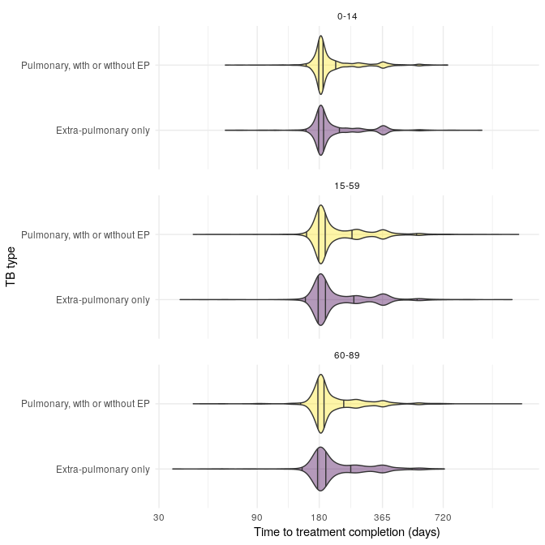

```r
  #' Plot
  ets_treat %>%
    drop_na(pulmextrapulm) %>%
    mutate(age_stage = age_stage %>%
             fct_recode(`0-14` = "child",
                        `15-59` = "adult",
                        `60-89` = "older adult")) %>%
    ggplot(aes(x = pulmextrapulm, y= as.numeric(timetocomplete),
               fill = pulmextrapulm)) +
  coord_flip() +
  scale_y_log10(breaks = c(30, 90, 180, 365, 720)) +
    geom_violin(alpha = 0.4, draw_quantiles = c(0.025, 0.25, 0.5, 0.75, 0.975)) +
  facet_wrap(~age_stage, ncol = 1) +
  scale_fill_viridis(discrete = TRUE) +
  theme_minimal() +
  theme(legend.position = "none") +
  labs(x = "TB type",
       y = "Time to treatment completion (days)")
```

```r
ggsave("figure/time_cure.png", dpi = 330)
```

There was little evidence to suggest that treatment time differed by pulmonary TB status but there was some evidence that treatment time differed by age. Older cases were more likely to be on treatment for longer, although the medians for each age group were similar.

```r
  #' Fit gamma distribution to the data
treat_gamma <- ets_treat %>%
  mutate(timetocomplete = timetocomplete / 365.25) %>%
  group_by(age_stage) %>%
  drop_na(timetocomplete) %>%
  nest %>%
  mutate(fit = map(data, ~fitdistr(.$timetocomplete %>%
                                  as.numeric %>%
                                  na.omit,
                                  densfun = "gamma",
                                  lower = c(0, 0)))) %>%
  mutate(density = map(data, ~ density(.$timetocomplete %>% as.numeric))) %>%
  mutate(density = map(density, ~ data.frame(x = .$x, y = .$y))) %>%
  mutate(fitted_y = map2(fit, density, ~ dgamma(.y$x,
                                                .x$estimate["shape"],
                                                .x$estimate["rate"]))
  ) %>%
  mutate(model_params = map(fit, ~ data.frame(parameter = "nu",
                                              description = "gamma",
                                              shape1 = .$estimate[1],
                                              shape2 = .$estimate[2])))
```

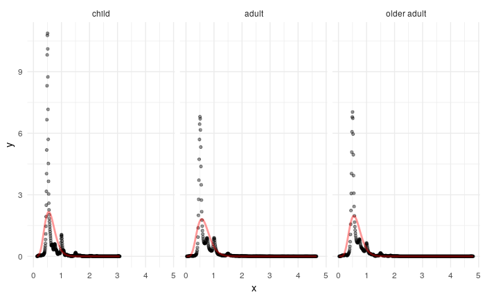

```r
treat_gamma %>%
  dplyr::select(-fit, -data, -model_params) %>%
  unnest() %>%
  ggplot(aes(x = x,y = y)) +
    geom_point(size = 1.2, alpha = 0.4) +
    geom_line(aes(y = fitted_y),
              color = "red", size = 1, alpha = 0.4) +
    theme_minimal() +
  facet_wrap(~age_stage)
```

```r
  #' Store fit
  treatment_time <- treat_gamma %>%
  dplyr::select(-data, -fit, -density, -fitted_y) %>%
  unnest

treatment_time
```

| age_stage | parameter | description | shape1 | shape2 |
| --- | --- | --- | --- | --- |
| adult | nu | gamma | 7.729171 | 11.94153 |
| child | nu | gamma | 9.861276 | 16.28078 |
| older adult | nu | gamma | 8.457496 | 13.61639 |

```r
  # Add to package
  devtools::use_data(treatment_time, overwrite = TRUE)
```

```
Saving treatment_time as treatment_time.rda to /home/modeltransvsdirect/ModelTransVsDirectBCG/data
```

```r
  #' Add as raw csv
  write_csv(treatment_time, "data-proc/treatment_time.csv")
```

Estimate TB mortality based on the proportion of cases that died from TB or from causes related to TB within the first year of starting treatment. Again limit the data to notifications from 2000 until 2014. This will underestimate TB mortality whilst on treatment as the majority of cases will have cleared treatment within 6 months of starting treatment.

```r
tb_mortality <- ets %>%
  filter(year <= 2014) %>%
  drop_na(finaloutcome12) %>%
  mutate(finaloutcome12 = finaloutcome12 %>%
           as.character %>%
           replace(finaloutcome12 %in% "Died" & DeathDueTB %in% "Yes", "TBDeath") %>%
           replace(finaloutcome12 %in% "Died" & DeathDueTB %in% "No", "OtherDeath") %>%
           replace(finaloutcome12 %in% "Died" & is.na(DeathDueTB), "NADeath") %>%
           factor) %>%
  count(finaloutcome12, age_stage, pulmextrapulm) %>%
  filter(!(finaloutcome12 %in% c("Not Evaluated", "Lost to follow up", "NADeath"))) %>%
  add_count(age_stage, pulmextrapulm, wt = n) %>%
  filter(finaloutcome12 %in% "TBDeath") %>%
  mutate(prop = n /nn,
         sd  = sqrt(prop * (1 - prop) / n))
```

```
Factor `pulmextrapulm` contains implicit NA, consider using `forcats::fct_explicit_na`Factor `pulmextrapulm` contains implicit NA, consider using `forcats::fct_explicit_na`Factor `pulmextrapulm` contains implicit NA, consider using `forcats::fct_explicit_na`
```

```r
tb_mortality
```

| finaloutcome12 | age_stage | pulmextrapulm | n | nn | prop | sd |
| --- | --- | --- | --- | --- | --- | --- |
| TBDeath | child | Extra-pulmonary only | 4 | 1103 | 0.003626473 | 0.03005546 |
| TBDeath | child | Pulmonary, with or without EP | 8 | 1935 | 0.004134367 | 0.02268610 |
| TBDeath | adult | Extra-pulmonary only | 21 | 4069 | 0.005160973 | 0.01563625 |
| TBDeath | adult | Pulmonary, with or without EP | 215 | 9569 | 0.022468388 | 0.01010723 |
| TBDeath | older adult | Extra-pulmonary only | 63 | 1438 | 0.043810848 | 0.02578650 |
| TBDeath | older adult | Pulmonary, with or without EP | 435 | 3877 | 0.112200155 | 0.01513246 |

```r
  # Add to package
  devtools::use_data(tb_mortality, overwrite = TRUE)
```

```
Saving tb_mortality as tb_mortality.rda to /home/modeltransvsdirect/ModelTransVsDirectBCG/data
```

```r
  #' Add as raw csv
  write_csv(tb_mortality, "data-proc/tb_mortality.csv")
```

Similarly the proportion lost to follow up is used to derive a prior for those lost to follow.

```r
tb_loss_follow <- ets %>%
  filter(year <= 2014) %>%
  drop_na(finaloutcome12, pulmextrapulm) %>%
  count(finaloutcome12, age_stage, pulmextrapulm) %>%
  filter(!(finaloutcome12 %in% c("Not Evaluated"))) %>%
  add_count(age_stage, pulmextrapulm, wt = n) %>%
  filter(finaloutcome12 %in% "Lost to follow up") %>%
  mutate(prop = n /nn,
         sd  = sqrt(prop * (1 - prop) / n))
tb_loss_follow
```

| finaloutcome12 | age_stage | pulmextrapulm | n | nn | prop | sd |
| --- | --- | --- | --- | --- | --- | --- |
| Lost to follow up | child | Extra-pulmonary only | 9 | 1115 | 0.008071749 | 0.029826528 |
| Lost to follow up | child | Pulmonary, with or without EP | 21 | 1959 | 0.010719755 | 0.022472037 |
| Lost to follow up | adult | Extra-pulmonary only | 119 | 4230 | 0.028132388 | 0.015157702 |
| Lost to follow up | adult | Pulmonary, with or without EP | 360 | 10105 | 0.035625928 | 0.009769101 |
| Lost to follow up | older adult | Extra-pulmonary only | 12 | 1591 | 0.007542426 | 0.024975885 |
| Lost to follow up | older adult | Pulmonary, with or without EP | 39 | 4603 | 0.008472735 | 0.014676816 |

```r
  # Add to package
  devtools::use_data(tb_loss_follow, overwrite = TRUE)
```

```
Saving tb_loss_follow as tb_loss_follow.rda to /home/modeltransvsdirect/ModelTransVsDirectBCG/data
```

```r
  #' Add as raw csv
  write_csv(tb_loss_follow, "data-proc/tb_loss_follow.csv")
```